# Multivariate Data Analysis Assignment #2

2018170865 산업경영공학부 박재현

2021. 4. 16. Fri.

### [Q1] 본인이 스스로 Logistic Regression 모델을 적용하는데 적합한 데이터셋을 선정하고 선정 이유를 설명하시오. 데이터셋 탐색은 아래에서 제시된 Data Repository를 포함하여 여러 Repository를 검색해서 결정하시오. 보고서에는 데이터를 다운로드할 수 있는 링크를 반드시 제공하시오.

타이타닉 데이터(https://www.kaggle.com/c/titanic/data)를 선정하였다.

#### 선정 이유

1. 캐글에 있는 데이터 셋 중에 유명한 데이터셋이다. 다른 사람들의 다양한 분석 결과들과 내 방법을 비교할 수 있다.
2. 예측하고자 하는 값(생존여부)이 생존/사망 2개로 분류되어있다. 따라서 명확한 분석 결과를 내기 용이하다.
3. 성별, 연령, 티켓 등급의 변수들이 생존에 어떠한 영향을 주는지에 대해 우리가 가지고 있는 상식과 실제 결과가 일치하는지에 대한 확인을 해볼 수 있다.
4. 예측하고자 하는 값(생존여부)을 로지스틱 리그레션 모델을 통해 확률로서 다루기 용이하다.

```r
data <- read.csv("train_titanic.csv", header=T, na.strings=c(""))
```

### [Q2] 해당 데이터셋의 종속변수와 설명변수는 어떤 것들이 있는가? 분석 전에 아래 세 가지 질문에 대해서 스스로 생각해보고 답변을 하시오.

| Variable | Definition | Key |
| --- | --- | --- |
| PassengerID | Passenger’s ID |  |
| Survied | Survival | 0 = No, 1 = Yes |
| Pclass | Ticket class | 1 = 1st, 2 = 2nd, 3 = 3rd |
| Name | Passenger’s name |  |
| Sex | Sex | male, female |
| Age | Age in years |  |
| Sibsp | # of siblings / spouses aboard the Titanic |  |
| Parch | # of parents / children aboard the Titanic |  |
| Ticket | Ticket number |  |
| Fare | Passenger fare |  |
| Cabin | Cabin number |  |
| Embarked | Port of Embarkation | C = Cherbourg, Q = Queenstown, S = Southampton |

#### 1. 이 데이터에서 제공된 설명변수들 중에서 높은 상관관계가 있을 것으로 예상되는 변수들은 어떤 것들이 있는가? 왜 그렇게 생각하는가?

Age와 Fare, Pclass. 나이가 많을 수록 부유할 확률이 높고, 높은 가격의 티켓을 지불할 능력이 있을 것으로 예상 된다. 따라서 객실의 등급도 높을 것이다. 상관관계를 계산해보면 Pclass와 Fare는 약 0.55의 상관관계를 가지고 있고, Age는 결측치가 존재하여 일단 계산 되지는 않았다.

```r
data_cor <- subset(data, select=c(Pclass, Age, SibSp, Parch, Fare))
cor(data_cor)
```

```
##             Pclass Age      SibSp      Parch       Fare
## Pclass  1.00000000  NA 0.08308136 0.01844267 -0.5494996
## Age             NA   1         NA         NA         NA
## SibSp   0.08308136  NA 1.00000000 0.41483770  0.1596510
## Parch   0.01844267  NA 0.41483770 1.00000000  0.2162249
## Fare   -0.54949962  NA 0.15965104 0.21622494  1.0000000
```

#### 2. 제공된 설명변수들 중에서 종속변수를 예측하는데 필요하지 않을 것으로 예상되는 변수들은 어떤 것들이 있는가? 왜 그렇게 생각하는가?

Embarked의 변수는 예측에 있어서 필요하지 않을 것으로 예상된다. 왜냐하면 배를 어디서 탑승했는지 여부가 배가 침몰하는 위기상황에 어떠한 영향도 끼치지 않을 것이라고 생각하기 때문이다. 다른 배가 아니라 하나의 배에서 일어난 사건이기 때문에 탑승 위치는 생존과 독립적이라고 생각한다.  
Name 변수는 예측에 있어서 의미를 가지지 않는 변수임으로 고려하지 않는다. 왜냐하면 승객 번호, 이름은 생존과 명백하게 독립이라고 생각할 수도 있고, 승객의 고유한 데이터에 해당한다. 또한 Cabin 변수는 결측치가 너무 많아서 예측에 사용하지 않기로 한다. Age와 Embarked에도 결측치가 존재하나 때문에 적절한 처리를 해주기로 결정한다.  
Age의 결측치가 177개인데, 단순히 결측치를 없애버리면 관측치의 개수가 적어지므로, 대표값을 결측치에 집어 넣어 주기로 하였다. 왜 데이터가 누락된 것인지, 특정 나이대의 데이터가 사라진 것인지 판단해봤을때, Age가 정규분포에 근사적으로 따르므로, 단순히 누락된 것으로 잠정지었다. 이에 따라 결측치에 평균값을 넣어주었다. 반면, Embarked는 최빈값을 넣어 주었다.

```r
sapply(data, function(x) length(unique(x))) # Unique value check
```

```
## PassengerId    Survived      Pclass        Name         Sex         Age
##         891           2           3         891           2          89
##       SibSp       Parch      Ticket        Fare       Cabin    Embarked
##           7           7         681         248         148           4
```

```r
sapply(data, function(x) sum(is.na(x))) # Missing value check
```

```
## PassengerId    Survived      Pclass        Name         Sex         Age
##           0           0           0           0           0         177
##       SibSp       Parch      Ticket        Fare       Cabin    Embarked
##           0           0           0           0         687           2
```

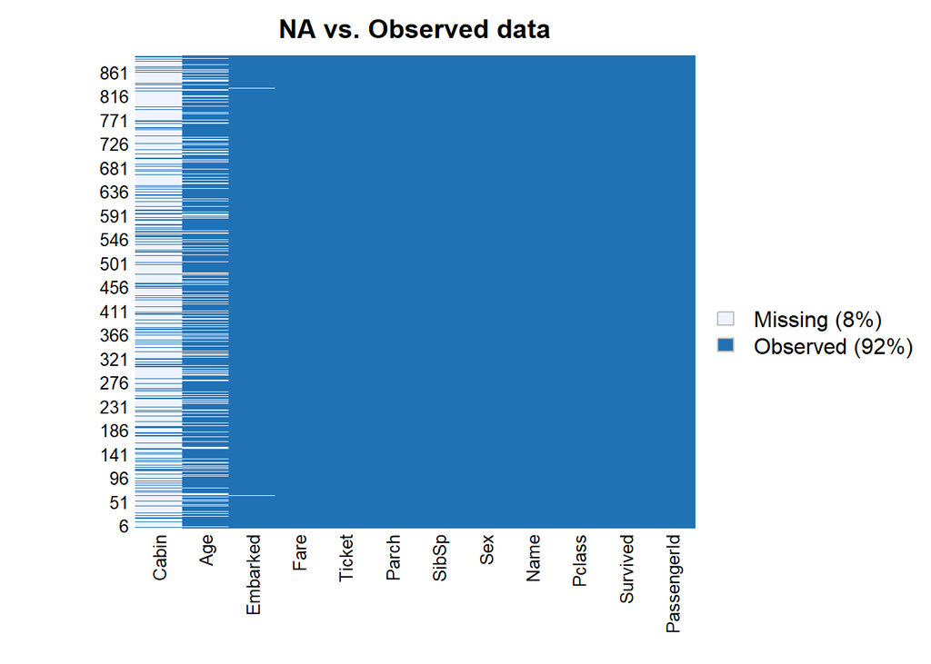

```r
missmap(data, main = "NA vs. Observed data")
```

```r
#data <- subset(data, select=-c(PassengerId, Name, Cabin, Ticket))
```

```r
# Age 처리
summary(data$Age)
```

```
##    Min. 1st Qu.  Median    Mean 3rd Qu.    Max.    NA's
##    0.42   20.12   28.00   29.70   38.00   80.00     177
```

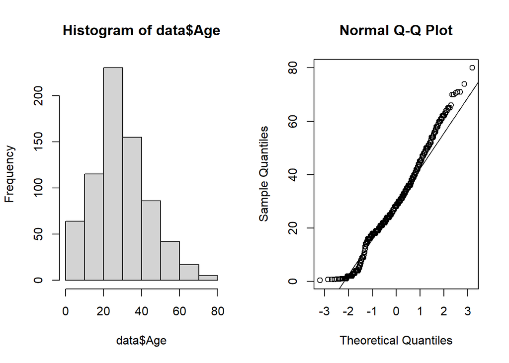

```r
par(mfrow = c(1, 2))
hist(data$Age)
qqnorm(data$Age)
qqline(data$Age)
```

```r
par(mfrow = c(1, 1))

data$Age[is.na(data$Age)] <- mean(data$Age,na.rm=T)

# Embarked
unique(data$Embarked)
```

```
## [1] "S" "C" "Q" NA
```

```r
length(data$Embarked[data$Embarked == 'S'])
```

```
## [1] 646
```

```r
length(data$Embarked[data$Embarked == 'C'])
```

```
## [1] 170
```

```r
length(data$Embarked[data$Embarked == 'Q'])
```

```
## [1] 79
```

```r
data$Embarked[is.na(data$Embarked)] <- 'S'
```

### [Q3] 모든 연속형 숫자 형태를 갖는(명목형변수 제외) 개별 입력 변수들에 대하여 각각 다음과 같은 단변 량 통계량을 계산하고 Box plot을 도시하시오: Mean, Standard deviation, Skewness, Kurtosis. 전체 변수 중에서 정규분포를 따른다고 할 수 있는 변수들은 몇 개인가? 정규분포를 따른다고 가정한 근거는 무엇인가?

Age변수가 정규분포를 가깝게 따른다. kurtosis가 3.95로 3보다 크나, skewness가 0에 가깝고, 박스플롯이 어느 대칭을 이루고 있고 있어서 근사적으로 정규분포를 따른다고 가정하고 진행하려고 한다. kurtosis 값을 보면 outlier들이 있을 것으로 예상된다. 추가적으로 Q-Q plot의 모양으로 판단하였다. 판단하였다.

> Sibsp 변수는 이산형 변수지만 [Q4]에서 필요하기 때문에 추가하였음.

|  | Age | Fare |
| --- | --- | --- |
| mean | 29.70 | 32.20 |
| sd | 13.00 | 49.69 |
| skewness | 0.43 | 4.78 |
| kurtosis | 3.95 | 36.20 |

```r
data_bp <- subset(data, select=c(Age, Fare))


mean <- sapply(data_bp, mean) # 평균
sd <-sapply(data_bp, sd) #표준편차
skewness <-sapply(data_bp, skewness) #skewness
kurtosis <-sapply(data_bp, kurtosis) #kurtosis

statistic <- rbind(mean, sd, skewness, kurtosis)
statistic
```

```
##                 Age      Fare
## mean     29.6991176 32.204208
## sd       13.0020152 49.693429
## skewness  0.4337563  4.779253
## kurtosis  3.9541389 36.204289
```

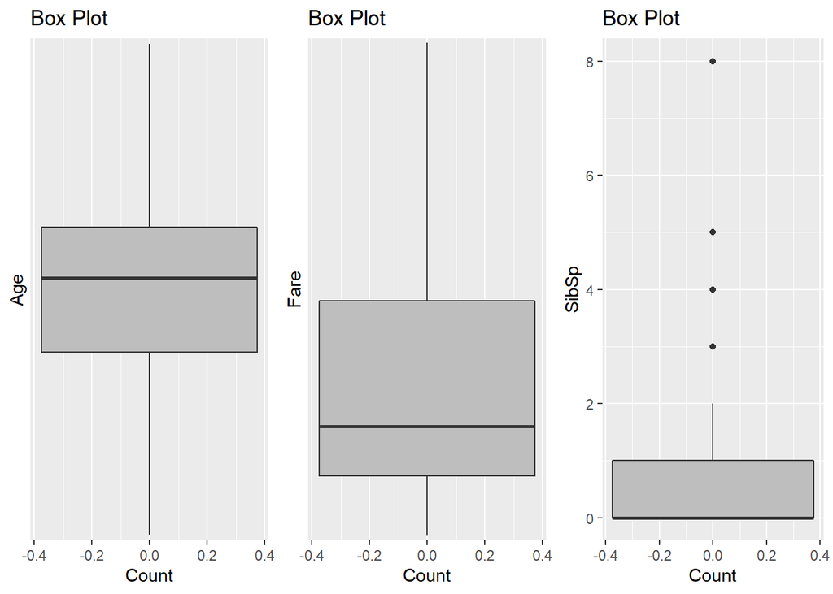

```r
bp1 <- ggplot(data, aes(y=Age)) +
  geom_boxplot(fill = "grey")+
  scale_y_discrete("Age")+
  labs(title = "Box Plot", x = "Count")

bp2 <- ggplot(data, aes(y=Fare)) +
  geom_boxplot(fill = "grey")+
  scale_y_discrete("Fare")+
  labs(title = "Box Plot", x = "Count")

bp3 <- ggplot(data, aes(y=SibSp)) +
  geom_boxplot(fill = "grey")+
  scale_y_continuous("SibSp")+
  labs(title = "Box Plot", x = "Count")

grid.arrange(bp1, bp2, bp3, nrow=1, ncol=3)
```

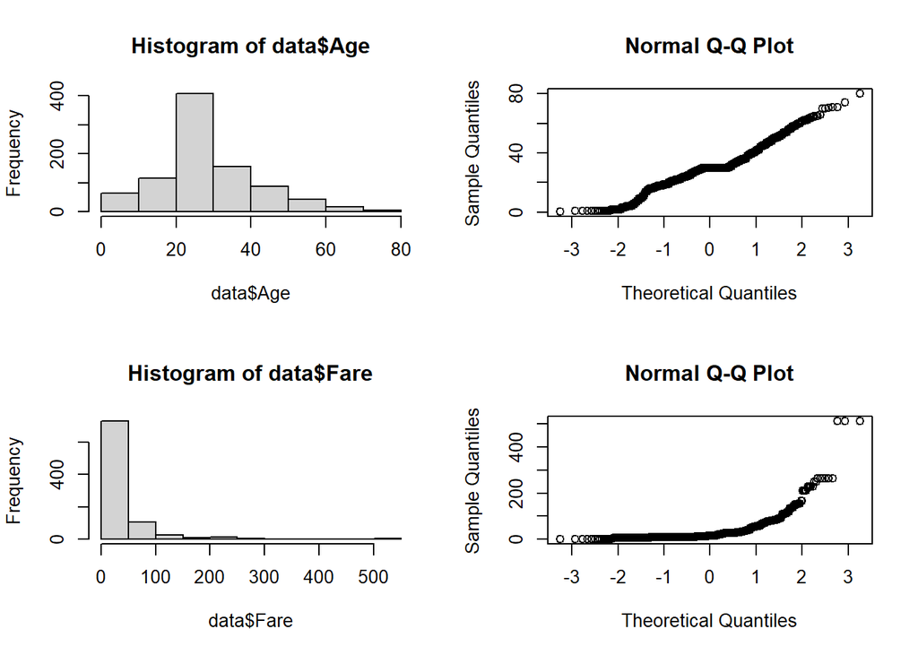

```r
par(mfrow = c(2, 2))

hist(data$Age)
qqnorm(data$Age)
hist(data$Fare)
qqnorm(data$Fare)
```

```r
par(mfrow = c(1, 1))
```

### [Q4] [Q3]의 Box plot을 근거로 각 변수들에 대한 이상치(너무 값이 크거나 작은 객체) 조건을 정의하고, 해당하는 객체들을 데이터셋에서 제거해 보시오.

Fare 변수에서 평균은 32.20인 반면, 최대값은 512.33이다. 또한 SibSp 변수에서 평균은 0.523, 중앙값은 0인 반면, 최대값은 8인 데이터가 존재한다. 따라서 2개 변수에 대해 Outlier를 정의하고 데이터셋에서 제거 할 것이다.

#### 이상치 조건

Fare : 90% 백분위수 이상인 관측치

Sibsp : Sibsp가 4이상인 관측치

```r
summary(data$Fare)
```

```
##    Min. 1st Qu.  Median    Mean 3rd Qu.    Max.
##    0.00    7.91   14.45   32.20   31.00  512.33
```

```r
quantile(data$Fare)
```

```
##       0%      25%      50%      75%     100%
##   0.0000   7.9104  14.4542  31.0000 512.3292
```

```r
quantile(data$Fare,probs=c(0.5, 0.75, 0.9, 0.95))
```

```
##      50%      75%      90%      95%
##  14.4542  31.0000  77.9583 112.0791
```

```r
nrow(data[data$Fare <= 77,])
```

```
## [1] 799
```

```r
summary(data$SibSp)
```

```
##    Min. 1st Qu.  Median    Mean 3rd Qu.    Max.
##   0.000   0.000   0.000   0.523   1.000   8.000
```

```r
nrow(data[data$SibSp >= 4,])
```

```
## [1] 30
```

```r
data <- filter(data, data$Fare <= 77, data$SibSp <= 3)
```

## 다음 각 물음에 대해서는 [Q4]에서 제거된 객체들을 제외시킨 데이터프레임을 사용하여 답하시오.

### [Q5] 가능한 모든 두 쌍의 입력 변수 조합에 대한 산점도(scatter plot) 및 Correlation plot (hint: “corrplot” 패키지의 corrplot( ) 함수 사용) 상관관계를 계산해 보시오.

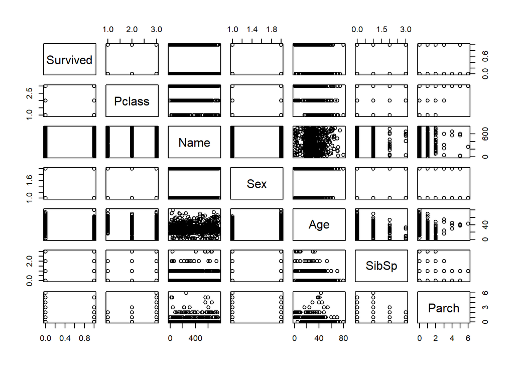

```r
plot(data[, (2:8)])
```

```r
data_cor <- subset(data, select=c(Pclass, Age, SibSp, Parch, Fare))
M <- cor(data_cor)
M
```

```
##             Pclass        Age       SibSp       Parch       Fare
## Pclass  1.00000000 -0.3272866  0.01458385  0.05295184 -0.6491698
## Age    -0.32728662  1.0000000 -0.18071868 -0.13637408  0.1571650
## SibSp   0.01458385 -0.1807187  1.00000000  0.29579401  0.3109770
## Parch   0.05295184 -0.1363741  0.29579401  1.00000000  0.2375892
## Fare   -0.64916979  0.1571650  0.31097699  0.23758921  1.0000000
```

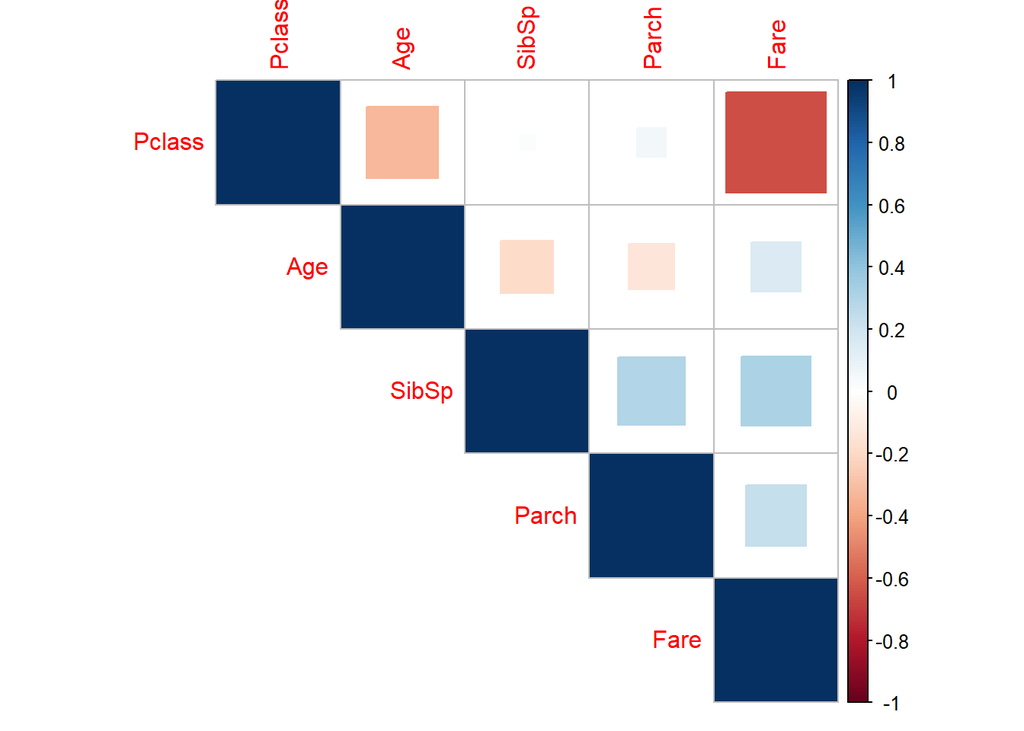

```r
corrplot(M, method="square", type="upper")
```

#### 1. 어떤 두 조합의 변수들이 서로 강한 상관관계가 있다고 할 수 있는가?

Pclass와 Fare는 0.65정도의 강한 음의 상관관계가 있다고 할 수 있다.

#### 2. 강한 상관관계가 존재 하는 변수 조합들 중에 대표 변수를 하나씩만 선택해서 전체변수의 개수를 감소 시켜보시오 ([Q7]에서 사용함)

Pclass는 순서가 있는 범주형 변수이고, Fare는 연속형 변수이다. 두 개의 변수중 분산이 큰 Fare 변수를 대표변수로 선택한다.

```r
data2 <- subset(data, select=-c(Pclass))
```

### [Q6] 전체 데이터셋을 70%의 학습 데이터와 30%의 테스트 데이터로 분할한 후 모든 변수를 사용하여 Logistic Regression 모델을 학습해 보시오. 이 때 70:30으로 구분하는 random seed를 저장하시오.

```r
set.seed(1)
ratio <- 0.7
indexes <- sample(2, nrow(data), replace=TRUE, prob=c(ratio, 1-ratio))
train <- data[indexes==1,]
test <- data[indexes==2,]

model <- glm(Survived ~ PassengerId + Pclass + Sex + Age + SibSp + Parch + Fare + Embarked, family=binomial(link='logit'), data=train)

summary(model)
```

```
##
## Call:
## glm(formula = Survived ~ PassengerId + Pclass + Sex + Age + SibSp +
##     Parch + Fare + Embarked, family = binomial(link = "logit"),
##     data = train)
##
## Deviance Residuals:
##     Min       1Q   Median       3Q      Max
## -2.0804  -0.5622  -0.4236   0.5803   2.5348
##
## Coefficients:
##               Estimate Std. Error z value Pr(>|z|)
## (Intercept)  5.0533782  0.9219411   5.481 4.22e-08 ***
## PassengerId -0.0001703  0.0004625  -0.368   0.7127
## Pclass      -0.8650314  0.2209539  -3.915 9.04e-05 ***
## Sexmale     -3.0692102  0.2795370 -10.980  < 2e-16 ***
## Age         -0.0520579  0.0113726  -4.577 4.71e-06 ***
## SibSp       -0.4267457  0.2198503  -1.941   0.0522 .
## Parch       -0.1465892  0.1575165  -0.931   0.3520
## Fare         0.0169552  0.0114303   1.483   0.1380
## EmbarkedQ    0.1298363  0.5275897   0.246   0.8056
## EmbarkedS   -0.2787544  0.3321303  -0.839   0.4013
## ---
## Signif. codes:  0 '***' 0.001 '**' 0.01 '*' 0.05 '.' 0.1 ' ' 1
##
## (Dispersion parameter for binomial family taken to be 1)
##
##     Null deviance: 699.24  on 539  degrees of freedom
## Residual deviance: 456.41  on 530  degrees of freedom
## AIC: 476.41
##
## Number of Fisher Scoring iterations: 5
```

#### 1. 유의수준 0.05에서 유효한 변수의 수는 몇 개 인지 확인하고 각 변수들이 본인의 상식선에서 실제로 유효하다고 할 수 있는지 판단해 보시오.

Pclass, Sex, Age 총 3개의 변수가 유의수준 0.05에서 유의하다.  
객실 등급이 높을 수록 생존율이 높다. 등급이 높을수록 위기 상황에서 우선적으로 도움을 받는게 상식이라고 생각되기 때문이다. 돈을 더 낸 만큼 더 좋은 대우를 받을 것으로 생각된다. 또한 여성일 수록 생존이 높다. Lady first라는 말이 있듯이 실제 재난상황에서 사회적 약자와 여자를 먼저 구출하는 경향이 있다. 따라서 성별은 상식과 다르지 않게 유효하다고 할 수 있다. 나이도 유효하다고 나오지만 실제로는 판단하기가 어렵다고 생각한다. 왜냐하면 노인과 어린이는 나이의 양 극단에 존재하는데, 상식적으로 두 그룹 모두 우선 구출 대상이기 때문이다. 아마도 탑승객중 많은 인원이 40~50대일 것이고, 그들을 중심으로 어린이들을 먼저 구출했기 때문에 유효하다는 결과가 나오는 것으로 생각된다.

#### 3. 학습데이터와 테스트 데이터에 대한 Confusion Matrix를 생성하고 Simple Accuracy, Balanced Correction Rate, F1-Measure를 산출하여 비교해 보시오.

| train | fitted |  |
| --- | --- | --- |
| actual | 1 | 0 |
| 1 | 128 | 61 |
| 0 | 38 | 313 |

| test | fitted |  |
| --- | --- | --- |
| actual | 1 | 0 |
| 1 | 48 | 33 |
| 0 | 30 | 118 |

|  | Accuracy | BCR | F1-Measure |
| --- | --- | --- | --- |
| train | 0.82 | 0.78 | 0.72 |
| test | 0.72 | 0.69 | 0.60 |

3개의 지표가 test 데이터에서 모두 하락했다.

```r
fitted_test <- predict(model, newdata = subset(test, select = c('PassengerId', 'Pclass', 'Sex', 'Age', 'SibSp','Parch', 'Fare', 'Embarked')), type = 'response')
fitted_test <- ifelse(fitted_test > 0.5,1,0)
fitted_train <- ifelse(model$fitted.values > 0.5,1,0)

# Confusion Matrix
cm_train <- xtabs(~ train$Survived + fitted_train) # train
cm_test <- xtabs(~ test$Survived + fitted_test) # test

perf_measure <- function(cm) {
  TPR <- cm[2,2]/sum(cm[2,]) # recall
  PRE <- cm[2,2]/sum(cm[,2]) # precision
  TNR <- cm[1,1]/sum(cm[1,]) # True Negative
  ACC <- (cm[1,1]+cm[2,2])/sum(cm)
  BCR <- sqrt(TPR*TNR)
  F1 <- 2*TPR*PRE/(TPR+PRE)

  return(c(ACC, BCR, F1))
}

perf_measure(cm_train)
```

```
## [1] 0.8166667 0.7771282 0.7211268
```

```r
perf_measure(cm_test)
```

```
## [1] 0.7248908 0.6873663 0.6037736
```

#### 4. 학습데이터와 테스트 데이터에 대한 AUROC를 산출하는 함수를 직접 작성하고 이를 사용하여 학습/테스트 데이터셋에 대한 AUROC를 비교해 보시오.

|  | train | test |
| --- | --- | --- |
| AUC | 0.854 | 0.806 |

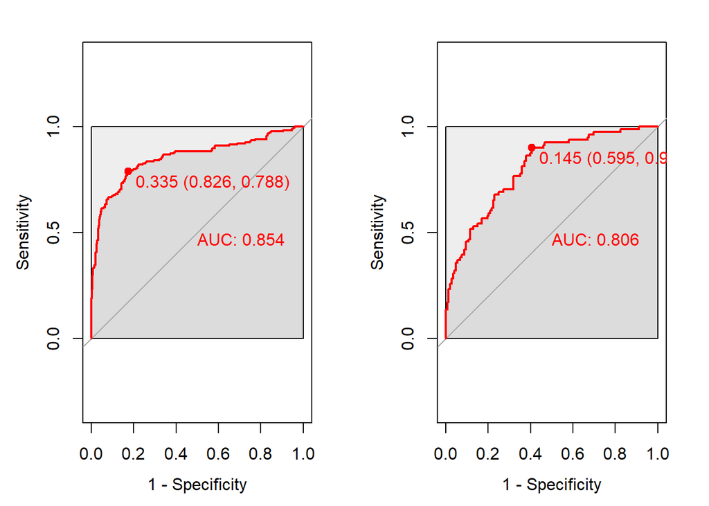

```r
# train
#pr_train <- prediction(fitted_train, train$Survived) # ROCR 패키지의 함수
#perf_train <- performance(pr_train, measure = "tpr", x.measure = "fpr")  # ROC
#plot(perf_train)

#auc_train <- performance(pr_train, measure = "auc")   # AUC
#auc_train <- auc_train@y.values[[1]]

# test
#pr_test <- prediction(fitted_test, test$Survived)
#perf_test <- performance(pr_test, measure = "tpr", x.measure = "fpr")
#plot(perf_test)

#auc_test <- performance(pr_test, measure = "auc")
#auc_test <- auc_test@y.values[[1]]

fitted_test <- predict(model, newdata = subset(test, select = c('PassengerId', 'Pclass', 'Sex', 'Age', 'SibSp','Parch', 'Fare', 'Embarked')), type = 'response')

par(mfrow = c(1, 2))
auroc_train = roc(Survived~fitted(model), data = train)
plot.roc(auroc_train, legacy.axes=T, col="red", print.auc=TRUE,
         max.auc.polygon=TRUE, print.thres=TRUE, print.thres.pch=19,
         print.thres.col = "red", auc.polygon=TRUE)

auroc_test = roc(Survived~fitted_test, data = test)
plot.roc(auroc_test, legacy.axes=T, col="red", print.auc=TRUE,
         max.auc.polygon=TRUE, print.thres=TRUE, print.thres.pch=19,
         print.thres.col = "red", auc.polygon=TRUE)
```

```r
par(mfrow = c(1, 1))
```

### [Q7] [Q5]에서 변수간 상관관계를 기준으로 선택한 변수들만을 사용하여 [Q6]에서 사용한 학습/테스트 70:30분할 데이터으로 Logistic Regression 모델을 학습해 보시오.

```r
indexes2 <- sample(2, nrow(data), replace=TRUE, prob=c(ratio, 1-ratio))
train2 <- data[indexes2==1,]
test2 <- data[indexes2==2,]

model2 <- glm(Survived ~ Sex + Age + SibSp + Parch + Fare + Embarked, family=binomial(link='logit'), data=train2)

summary(model2)
```

```
##
## Call:
## glm(formula = Survived ~ Sex + Age + SibSp + Parch + Fare + Embarked,
##     family = binomial(link = "logit"), data = train2)
##
## Deviance Residuals:
##     Min       1Q   Median       3Q      Max
## -1.8556  -0.5819  -0.4602   0.7145   2.5236
##
## Coefficients:
##              Estimate Std. Error z value Pr(>|z|)
## (Intercept)  1.749562   0.466887   3.747 0.000179 ***
## Sexmale     -2.583398   0.257907 -10.017  < 2e-16 ***
## Age         -0.036324   0.010800  -3.363 0.000770 ***
## SibSp       -0.722141   0.222529  -3.245 0.001174 **
## Parch       -0.094211   0.189997  -0.496 0.619997
## Fare         0.054167   0.008788   6.164  7.1e-10 ***
## EmbarkedQ   -0.226687   0.447483  -0.507 0.612448
## EmbarkedS   -0.624807   0.308094  -2.028 0.042563 *
## ---
## Signif. codes:  0 '***' 0.001 '**' 0.01 '*' 0.05 '.' 0.1 ' ' 1
##
## (Dispersion parameter for binomial family taken to be 1)
##
##     Null deviance: 683.88  on 533  degrees of freedom
## Residual deviance: 478.92  on 526  degrees of freedom
## AIC: 494.92
##
## Number of Fisher Scoring iterations: 5
```

#### 2. 학습데이터와 테스트 데이터에 대한 Confusion Matrix를 생성하고 Simple Accuracy, Balanced Correction Rate, F1-Measure를 산출한 뒤, [Q6-3]의 결과와 비교해 보시오.

| train | fitted |  |
| --- | --- | --- |
| actual | 1 | 0 |
| 1 | 121 | 60 |
| 0 | 51 | 302 |

| test | fitted |  |
| --- | --- | --- |
| actual | 1 | 0 |
| 1 | 55 | 34 |
| 0 | 23 | 123 |

|  | Accuracy | BCR | F1-Measure |
| --- | --- | --- | --- |
| train | 0.79 | 0.76 | 0.69 |
| test | 0.76 | 0.72 | 0.66 |

```r
fitted_test2 <- predict(model2, newdata = subset(test2, select = c('Sex', 'Age', 'SibSp','Parch', 'Fare', 'Embarked')), type = 'response')
fitted_test2 <- ifelse(fitted_test2 > 0.5,1,0)
fitted_train2 <- ifelse(model2$fitted.values > 0.5,1,0)

# Confusion Matrix
cm2_train <- xtabs(~ train2$Survived + fitted_train2) # train
cm2_test <- xtabs(~ test2$Survived + fitted_test2) # test

perf_measure(cm2_train)
```

```
## [1] 0.7921348 0.7562572 0.6855524
```

```r
perf_measure(cm2_test)
```

```
## [1] 0.7574468 0.7215434 0.6586826
```

#### 3. 학습/테스트 데이터셋에 대한 AUROC를 산출하여 [Q6-4]의 결과와 비교해 보시오.

|  | train | test |
| --- | --- | --- |
| AUC | 0.840 | 0.810 |

[Q6-4]의 결과보다 성능이 좋아진다. AUROC의 넓이가 train 데이터셋에서는 작아지는 반면, test 데이터셋에서는 넓어진다. 이는 overfitting되지 않고, 유효하지 않은 변수를 줄임으로서 성능이 높아졌다고 해석할 수 있다.

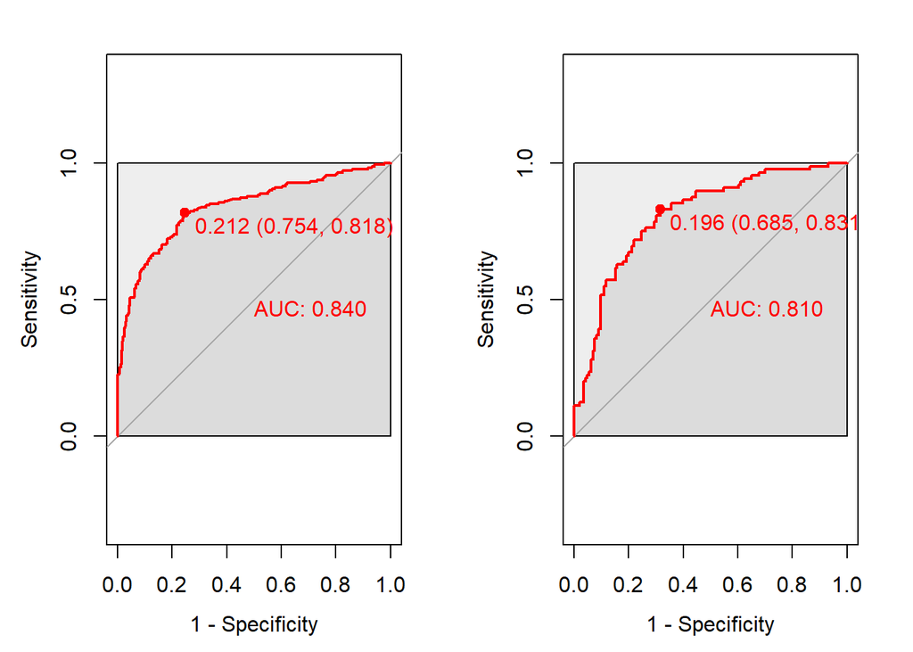

```r
# train
#pr2_train <- prediction(fitted_train2, train2$Survived) # ROCR 패키지의 함수
#perf2_train <- performance(pr2_train, measure = "tpr", x.measure = "fpr")  # ROC
#plot(perf2_train)

#auc2_train <- performance(pr2_train, measure = "auc")   # AUC
#auc2_train <- auc2_train@y.values[[1]]
#auc2_train

# test
#pr2_test <- prediction(fitted_test2, test2$Survived) # ROCR 패키지의 함수
#perf2_test <- performance(pr2_test, measure = "tpr", x.measure = "fpr")  # ROC
#plot(perf2_test)

#auc2_test <- performance(pr2_test, measure = "auc")   # AUC
#auc2_test <- auc2_test@y.values[[1]]
#auc2_test

fitted_test2 <- predict(model2, newdata = subset(test2, select = c('Sex', 'Age', 'SibSp','Parch', 'Fare', 'Embarked')), type = 'response')

par(mfrow = c(1, 2))
auroc_train2 = roc(Survived~fitted(model2), data = train2)
plot.roc(auroc_train2, legacy.axes=T, col="red", print.auc=TRUE,
         max.auc.polygon=TRUE, print.thres=TRUE, print.thres.pch=19,
         print.thres.col = "red", auc.polygon=TRUE)

auroc_test2 = roc(Survived~fitted_test2, data = test2)
plot.roc(auroc_test2, legacy.axes=T, col="red", print.auc=TRUE,
         max.auc.polygon=TRUE, print.thres=TRUE, print.thres.pch=19,
         print.thres.col = "red", auc.polygon=TRUE)
```

```r
par(mfrow = c(1, 1))
```

### (Optional) [Q8] 이외 본인이 선택한 데이터셋에 Logistic Regression을 통해 분석/검증 해볼 수 있는 아이디어를 제시하고 이에 대한 절차와 분석결과를 설명하시오.

변수 Age의 대한 나의 생각은 노인과 아이가 모두 우선 구출되었을 것이라는 판단이었다. 즉, Age 변수는 별로 유의하지 않을 것이라고 생각했는데, 모델에 의하면 매우 유의한 변수이고, 나이가 한 단위 증가할 수록 -0.04만 큼 예측값이 감소한다.

실제로 아이들이 많이 생존했을지에 대해 분석을 해보고자 한다. Child 변수를 만들어서 Age변수 대신 사용한다. 다른 변수들은 비교, 분석을 위해 그대로 사용한다.

```r
summary(data$Age)
```

```
##    Min. 1st Qu.  Median    Mean 3rd Qu.    Max.
##    0.42   23.00   29.70   29.85   34.00   80.00
```

```r
data$Child <- 0
data$Child[data$Age < 18] <- 1

table(data$Child, data$Survived)
```

```
##
##       0   1
##   0 468 220
##   1  31  50
```

```r
prop.table(table(data$Child, data$Survived),1)
```

```
##
##             0         1
##   0 0.6802326 0.3197674
##   1 0.3827160 0.6172840
```

```r
indexes3 <- sample(2, nrow(data), replace=TRUE, prob=c(ratio, 1-ratio))
train3 <- data[indexes3==1,]
test3 <- data[indexes3==2,]

aggregate(Survived ~ Child, data=train3, FUN=sum) # 살아남은 사람들의 숫자
```

| Child | Survived |
| --- | --- |
| 0 | 154 |
| 1 | 35 |

```r
aggregate(Survived ~ Child, data=train3, FUN=length) # 각 그룹별 사람들의 총 숫자
```

| Child | Survived |
| --- | --- |
| 0 | 486 |
| 1 | 55 |

```r
aggregate(Survived ~ Child, data=train3, FUN=function(x) {sum(x)/length(x)}) #각 그룹별 생존률
```

| Child | Survived |
| --- | --- |
| 0 | 0.3168724 |
| 1 | 0.6363636 |

```r
model3 <- glm(Survived ~ Sex + Child + SibSp + Parch + Fare + Embarked, family=binomial(link='logit'), data=train3)

summary(model3)
```

```
##
## Call:
## glm(formula = Survived ~ Sex + Child + SibSp + Parch + Fare +
##     Embarked, family = binomial(link = "logit"), data = train3)
##
## Deviance Residuals:
##     Min       1Q   Median       3Q      Max
## -2.4611  -0.5766  -0.4985   0.7667   2.3209
##
## Coefficients:
##              Estimate Std. Error z value Pr(>|z|)
## (Intercept)  0.620897   0.367242   1.691  0.09089 .
## Sexmale     -2.617489   0.254769 -10.274  < 2e-16 ***
## Child        1.725380   0.391616   4.406 1.05e-05 ***
## SibSp       -0.597008   0.205991  -2.898  0.00375 **
## Parch       -0.365113   0.163646  -2.231  0.02567 *
## Fare         0.043757   0.008007   5.465 4.63e-08 ***
## EmbarkedQ   -0.103667   0.465492  -0.223  0.82377
## EmbarkedS   -0.369755   0.297450  -1.243  0.21384
## ---
## Signif. codes:  0 '***' 0.001 '**' 0.01 '*' 0.05 '.' 0.1 ' ' 1
##
## (Dispersion parameter for binomial family taken to be 1)
##
##     Null deviance: 700.10  on 540  degrees of freedom
## Residual deviance: 502.69  on 533  degrees of freedom
## AIC: 518.69
##
## Number of Fisher Scoring iterations: 4
```

```r
fitted_test3 <- predict(model3, newdata = subset(test3, select = c('Sex', 'Child', 'SibSp', 'Parch', 'Fare', 'Embarked')), type = 'response')
fitted_test3 <- ifelse(fitted_test3 > 0.5,1,0)
fitted_train3 <- ifelse(model3$fitted.values > 0.5,1,0)

# Confusion Matrix
cm3_train <- xtabs(~ train3$Survived + fitted_train3) # train
cm3_test <- xtabs(~ test3$Survived + fitted_test3) # test

perf_measure(cm3_train)
```

```
## [1] 0.7948244 0.7533894 0.6890756
```

```r
perf_measure(cm3_test)
```

```
## [1] 0.7850877 0.7529233 0.6878981
```

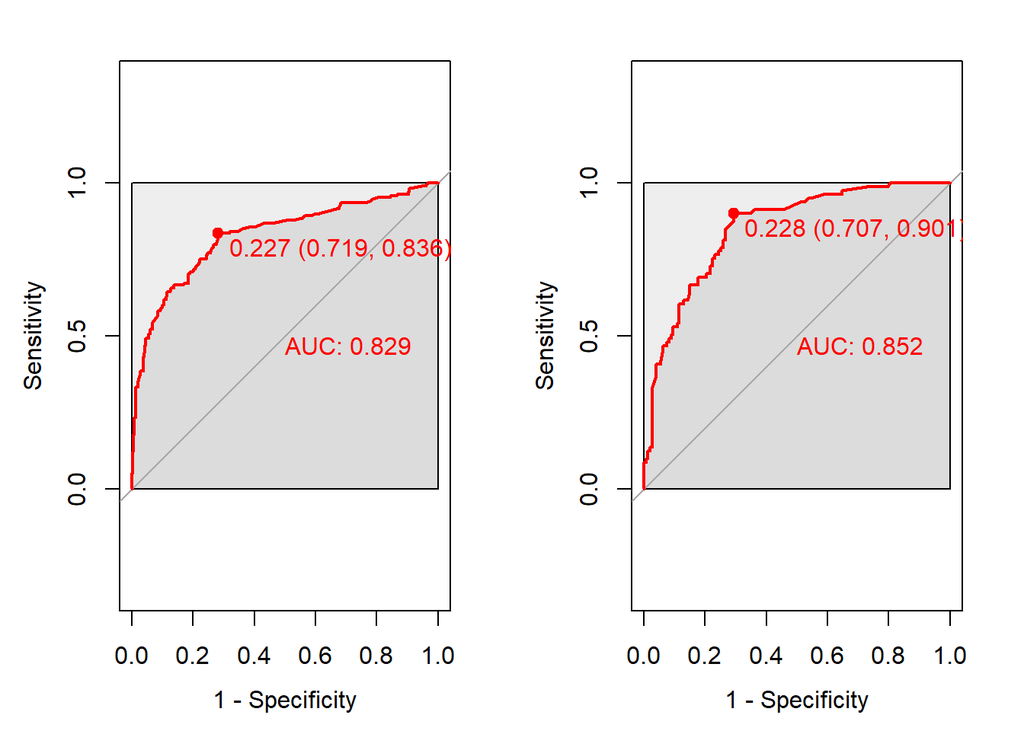

```r
# train
#pr3_train <- prediction(fitted_train3, train3$Survived) # ROCR 패키지의 함수
#perf3_train <- performance(pr3_train, measure = "tpr", x.measure = "fpr")  # ROC
#plot(perf3_train)

#auc3_train <- performance(pr3_train, measure = "auc")   # AUC
#auc3_train <- auc3_train@y.values[[1]]
#auc3_train

# test
#pr3_test <- prediction(fitted_test3, test3$Survived) # ROCR 패키지의 함수
#perf3_test <- performance(pr3_test, measure = "tpr", x.measure = "fpr")  # ROC
#plot(perf3_test)

#auc3_test <- performance(pr3_test, measure = "auc")   # AUC
#auc3_test <- auc3_test@y.values[[1]]
#auc3_test

fitted_test3 <- predict(model3, newdata = subset(test3, select = c('Sex', 'Child', 'SibSp', 'Parch', 'Fare', 'Embarked')), type = 'response')

par(mfrow = c(1, 2))
auroc_train3 = roc(Survived~fitted(model3), data = train3)
plot.roc(auroc_train3, legacy.axes=T, col="red", print.auc=TRUE,
         max.auc.polygon=TRUE, print.thres=TRUE, print.thres.pch=19,
         print.thres.col = "red", auc.polygon=TRUE)

auroc_test3 = roc(Survived~fitted_test3, data = test3)
plot.roc(auroc_test3, legacy.axes=T, col="red", print.auc=TRUE,
         max.auc.polygon=TRUE, print.thres=TRUE, print.thres.pch=19,
         print.thres.col = "red", auc.polygon=TRUE)
```

```r
par(mfrow = c(1, 1))
```